**Homework 1**

*Youkyoung JEONG*

*09.04.2015*

**Part A - Load gapminder data**

Import the data with `read.delim()` and with `read.table()`.

- Load the Gapminder data with both functions without specifying args other than file. Do you get the same resulting object in your workspace? Use all the ways we’ve learned to inspect an object to back up your claims with hard facts.

```r
gapminder <- read.delim("http://www.stat.ubc.ca/~jenny/notOcto/STAT545A/examples/gapminder/data/gapminderDataFiveYear.txt")
str(gapminder)
```

```
## 'data.frame':    1704 obs. of  6 variables:
##  $ country  : Factor w/ 142 levels "Afghanistan",..: 1 1 1 1 1 1 1 1 1 1 ...
##  $ year     : int  1952 1957 1962 1967 1972 1977 1982 1987 1992 1997 ...
##  $ pop      : num  8425333 9240934 10267083 11537966 13079460 ...
##  $ continent: Factor w/ 5 levels "Africa","Americas",..: 3 3 3 3 3 3 3 3 3 3 ...
##  $ lifeExp  : num  28.8 30.3 32 34 36.1 ...
##  $ gdpPercap: num  779 821 853 836 740 ...
```

```r
# read.table function failed
# gapminder.tab <- read.table("http://www.stat.ubc.ca/~jenny/notOcto/STAT545A/examples/gapminder/data/gapminderDataFiveYear.txt")
```

: Without any settings, an error occured while loading the data set using `read.table()` function. On the other hand, `read.delim` seems to work well.

- If you’re not getting the same object, why not?

: Since the raw data is separated by tap, `read.delim` worked well as reading in delimited text file. However, as the default setting of `read.table` clutter the texts, it failed to load the data.

- Develop the call to `read.table()` that is equivalent to `read.delim()`

```r
#Attach knitr
library(knitr)

#Using the option "sep"
gapminder.tab <- read.table("http://www.stat.ubc.ca/~jenny/notOcto/STAT545A/examples/gapminder/data/gapminderDataFiveYear.txt", sep="\t")
```

```r
kable(head(gapminder.tab))
```

| V1 | V2 | V3 | V4 | V5 | V6 |
| --- | --- | --- | --- | --- | --- |
| country | year | pop | continent | lifeExp | gdpPercap |
| Afghanistan | 1952 | 8425333 | Asia | 28.801 | 779.4453145 |
| Afghanistan | 1957 | 9240934 | Asia | 30.332 | 820.8530296 |
| Afghanistan | 1962 | 10267083 | Asia | 31.997 | 853.10071 |
| Afghanistan | 1967 | 11537966 | Asia | 34.02 | 836.1971382 |
| Afghanistan | 1972 | 13079460 | Asia | 36.088 | 739.9811058 |

: After setting the `sep` option to delimit the data by tap, `read.table` worked. However, as seen in the table above, the first row is recognized as one of the cases.

```r
#Using the option "head"
gapminder.tab.h <- read.table("http://www.stat.ubc.ca/~jenny/notOcto/STAT545A/examples/gapminder/data/gapminderDataFiveYear.txt",head=TRUE, sep="\t")
```

```r
kable(head(gapminder.tab.h))
```

| country | year | pop | continent | lifeExp | gdpPercap |
| --- | --- | --- | --- | --- | --- |
| Afghanistan | 1952 | 8425333 | Asia | 28.801 | 779.4453 |
| Afghanistan | 1957 | 9240934 | Asia | 30.332 | 820.8530 |
| Afghanistan | 1962 | 10267083 | Asia | 31.997 | 853.1007 |
| Afghanistan | 1967 | 11537966 | Asia | 34.020 | 836.1971 |
| Afghanistan | 1972 | 13079460 | Asia | 36.088 | 739.9811 |
| Afghanistan | 1977 | 14880372 | Asia | 38.438 | 786.1134 |

: As using the option `head`, the first row is designated as column name.

```r
kable(gapminder.tab.h[361:366, ])
```

|  | country | year | pop | continent | lifeExp | gdpPercap |
| --- | --- | --- | --- | --- | --- | --- |
| 361 | Cote dIvoire 1952 2977019 Africa 40.477 1388.594732 |  |  |  |  |  |
| Cote d | Ivoire 1957 3300000 Africa 42.469 1500.896 |  |  |  |  |  |
| 362 | Cote dIvoire 1962 3832408 Africa 44.93 1728.869428 |  |  |  |  |  |
| Cote d | Ivoire 1967 4744870 Africa 47.350 2052.050 |  |  |  |  |  |
| 363 | Cote dIvoire 1972 6071696 Africa 49.801 2378.201111 |  |  |  |  |  |
| Cote d | Ivoire 1977 7459574 Africa 52.374 2517.737 |  |  |  |  |  |
| 364 | Cote dIvoire 1982 9025951 Africa 53.983 2602.710169 |  |  |  |  |  |
| Cote d | Ivoire 1987 10761098 Africa 54.655 2156.956 |  |  |  |  |  |
| 365 | Cote dIvoire 1992 12772596 Africa 52.044 1648.073791 |  |  |  |  |  |
| Cote d | Ivoire 1997 14625967 Africa 47.991 1786.265 |  |  |  |  |  |
| 366 | Cote dIvoire 2002 16252726 Africa 46.832 1648.800823 |  |  |  |  |  |
| Cote d | Ivoire 2007 18013409 Africa 48.328 1544.750 |  |  |  |  |  |

: However, as seen above, `read.table` seems to clutter the text file containing “Cote d’Ivoire.” Thus, it was not possible to load the data with `read.table` exactly same as `read.delim`.

**Part B - Data smell test**

Explore your new data.frame.

- Is it a data.frame, a matrix, a vector, a list?

```r
str(gapminder)
```

```
## 'data.frame':    1704 obs. of  6 variables:
##  $ country  : Factor w/ 142 levels "Afghanistan",..: 1 1 1 1 1 1 1 1 1 1 ...
##  $ year     : int  1952 1957 1962 1967 1972 1977 1982 1987 1992 1997 ...
##  $ pop      : num  8425333 9240934 10267083 11537966 13079460 ...
##  $ continent: Factor w/ 5 levels "Africa","Americas",..: 3 3 3 3 3 3 3 3 3 3 ...
##  $ lifeExp  : num  28.8 30.3 32 34 36.1 ...
##  $ gdpPercap: num  779 821 853 836 740 ...
```

: It is a data frame.

- What’s its mode, class?

```r
class(gapminder)
```

```
## [1] "data.frame"
```

: Its class is ‘data.frame.’

- How many variables?

: There are six variables.

- How many rows/observations?

: There are 1704 observations.

- Can you get these facts about “extent” or “size” in more than one way? Can you imagine different functions being useful in different contexts?

```r
ncol(gapminder)
```

```
## [1] 6
```

: `ncol` can be used to identify the number of the variables.

```r
nrow(gapminder)
```

```
## [1] 1704
```

: `nrow` can be used to identify the number of the observations.

```r
dim(gapminder)
```

```
## [1] 1704    6
```

: `dim` can be used to identify the number of the variables and the observations of an object.

**Part C - Explore individual variables**

Pick at least one categorical variable and at least one quantitiative variable to explore.

: I selected `continent` as a categorical variable and `lifeExp` as a quantitative variable.

- Characterize what’s possible, i.e. all possible values or max vs. min … whatever’s appropriate.

```r
unique(gapminder$continent)
```

```
## [1] Asia     Europe   Africa   Americas Oceania
## Levels: Africa Americas Asia Europe Oceania
```

: To show all possible values in `continent`, I used `unique` functions. As above, the categorical variable `continent` has 5 different values.

To characterize the quantitative variable, I used `max` and `min`.

```r
max(gapminder$lifeExp)
```

```
## [1] 82.603
```

```r
min(gapminder$lifeExp)
```

```
## [1] 23.599
```

- What’s typical? What’s the spread? What’s the distribution?
1. Typical value

```r
summary(gapminder$lifeExp)
```

```
##    Min. 1st Qu.  Median    Mean 3rd Qu.    Max.
##   23.60   48.20   60.71   59.47   70.85   82.60
```

: Table above indicates the median and the mean of the life expectancy, as well as the quartiles that can show the spread of the data.

2. Spread

```r
#Range
max(gapminder$lifeExp)-min(gapminder$lifeExp)
```

```
## [1] 59.004
```

```r
#Range command could also be used to show the maximum and minimum value
range(gapminder$lifeExp)
```

```
## [1] 23.599 82.603
```

```r
#Standard deviation
sd(gapminder$lifeExp)
```

```
## [1] 12.91711
```

: Along with the five-number summary, `range` and standard deviation(`sd`) can also show the spread of the data.

3. Distribution

```r
table(gapminder$continent)
```

```
##
##   Africa Americas     Asia   Europe  Oceania
##      624      300      396      360       24
```

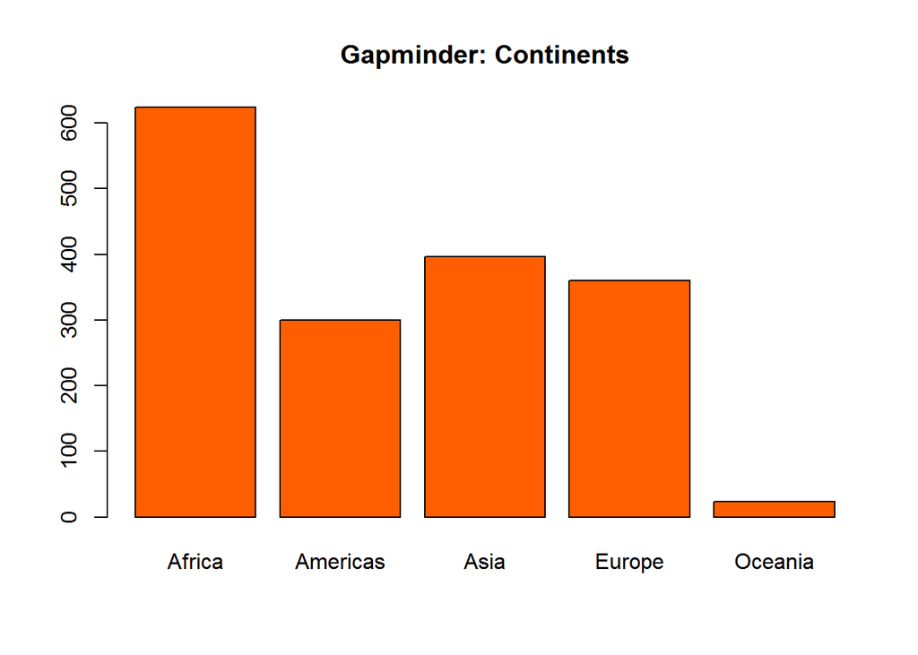

```r
barplot(table(gapminder$continent), main="Gapminder: Continents", col="#FF5E00")
```

: With `table` and `barplot` command, the frequency table and the bar plot of `continent` can be derived.

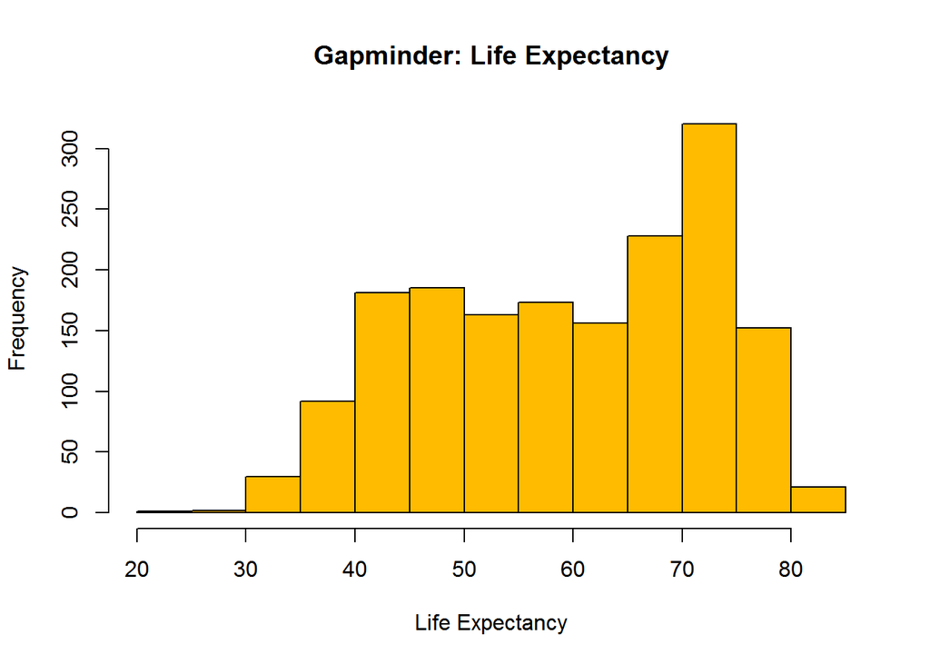

```r
hist(gapminder$lifeExp,main="Gapminder: Life Expectancy",xlab="Life Expectancy", col="#FFBB00")
```

: `hist` can be used to show the distribution of `lifeExp`.

**Part D - Getting down to business**

Attack each of the tasks below with a table and figure.

- Base R tools (e.g., subset, logicals) and `dplyr` should be your main data manipulation tools

```r
#Attach dplyr
library(dplyr)
```

- `ggplot2` should be your main visualization tool

```r
#Attach ggplot2
library(ggplot2)
```

**Task menu**

1. Get the maximum and minimum of GDP per capita for all continents.

```r
kable(gapminder%>%group_by(continent)%>%
        summarise(Maximum=max(gdpPercap),Minimum=min(gdpPercap)))
```

| continent | Maximum | Minimum |
| --- | --- | --- |
| Africa | 21951.21 | 241.1659 |
| Americas | 42951.65 | 1201.6372 |
| Asia | 113523.13 | 331.0000 |
| Europe | 49357.19 | 973.5332 |
| Oceania | 34435.37 | 10039.5956 |

2. Look at the spread of GDP per capita within the continents.

```r
kable(gapminder%>%group_by(continent)%>%
        summarise(Range=max(gdpPercap)-min(gdpPercap),SD=sd(gdpPercap)))
```

[output not shown]

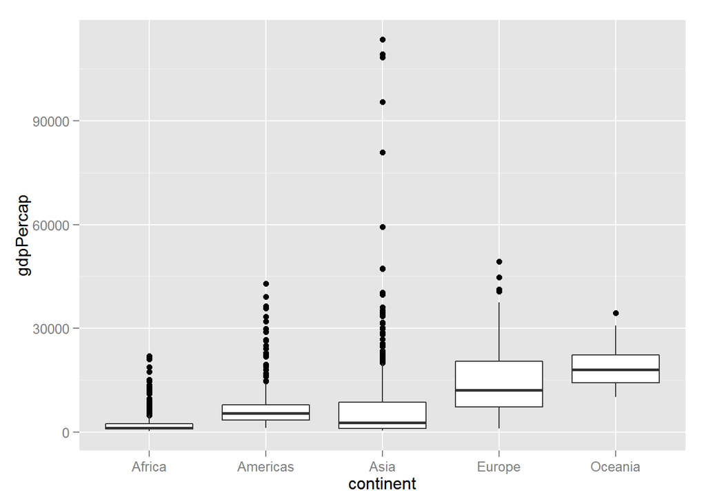

```r
ggplot(gapminder,aes(x=continent,y=gdpPercap))+geom_boxplot()
```

: Also, the five-number summary can be displayed via box plot.

3. Compute a trimmed mean of life expectancy for different years. Or a weighted mean, weighting by population. Just try something other than the plain vanilla mean.
- Trimmed mean & Weighted mean, weighting by population

```r
Trimmed.weighted.mean <- gapminder%>%group_by(year)%>%
  summarize(Trimmed.mean=mean(lifeExp, trim=0.2),
            Weighted.mean=weighted.mean(lifeExp,pop))%>%
  mutate(Trimmed.mean=round(Trimmed.mean,2),
         Weighted.mean=round(Weighted.mean,2))
```

```r
kable(Trimmed.weighted.mean)
```

| year | Trimmed.mean | Weighted.mean |
| --- | --- | --- |
| 1952 | 47.75 | 48.94 |
| 1957 | 50.64 | 52.12 |
| 1962 | 53.13 | 52.32 |
| 1967 | 55.64 | 56.98 |
| 1972 | 58.12 | 59.51 |
| 1977 | 60.39 | 61.24 |
| 1982 | 62.47 | 62.88 |
| 1987 | 64.48 | 64.42 |
| 1992 | 65.89 | 65.65 |
| 1997 | 66.84 | 66.85 |
| 2002 | 67.77 | 67.84 |
| 2007 | 69.17 | 68.92 |

- The trimmed and weighted mean can be displayed by line graph as below.

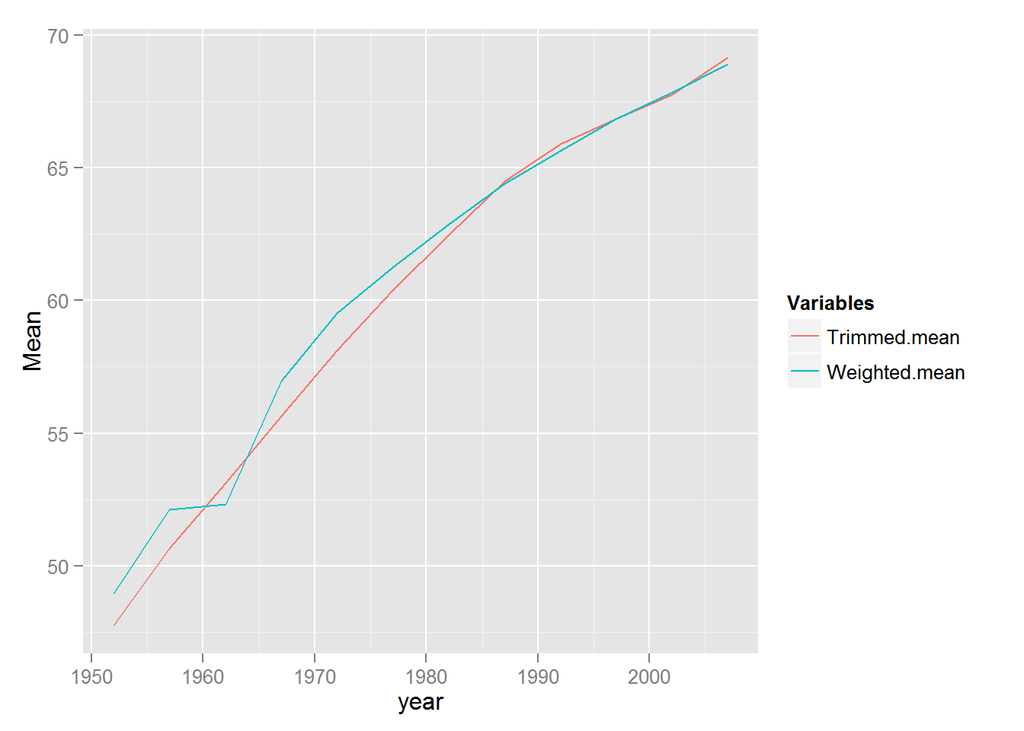

```r
ggplot(Trimmed.weighted.mean, aes(year)) +
  geom_line(aes(y = Trimmed.mean, colour = "Trimmed.mean")) +
  geom_line(aes(y = Weighted.mean, colour = "Weighted.mean")) +
  ylab("Mean") + labs(colour="Variables")
```

4. How is life expectancy changing over time on different continents?

```r
#Attach tidyr
library(tidyr)
Cont.life<-gapminder%>%group_by(continent,year)%>%
  summarize(mean=mean(lifeExp))
```

```r
kable(Cont.life%>%mutate(mean=round(mean,2))%>%spread(year,mean))
```

| continent | 1952 | 1957 | 1962 | 1967 | 1972 | 1977 | 1982 | 1987 | 1992 | 1997 | 2002 | 2007 |
| --- | --- | --- | --- | --- | --- | --- | --- | --- | --- | --- | --- | --- |
| Africa | 39.14 | 41.27 | 43.32 | 45.33 | 47.45 | 49.58 | 51.59 | 53.34 | 53.63 | 53.60 | 53.33 | 54.81 |
| Americas | 53.28 | 55.96 | 58.40 | 60.41 | 62.39 | 64.39 | 66.23 | 68.09 | 69.57 | 71.15 | 72.42 | 73.61 |
| Asia | 46.31 | 49.32 | 51.56 | 54.66 | 57.32 | 59.61 | 62.62 | 64.85 | 66.54 | 68.02 | 69.23 | 70.73 |
| Europe | 64.41 | 66.70 | 68.54 | 69.74 | 70.78 | 71.94 | 72.81 | 73.64 | 74.44 | 75.51 | 76.70 | 77.65 |
| Oceania | 69.25 | 70.30 | 71.09 | 71.31 | 71.91 | 72.85 | 74.29 | 75.32 | 76.94 | 78.19 | 79.74 | 80.72 |

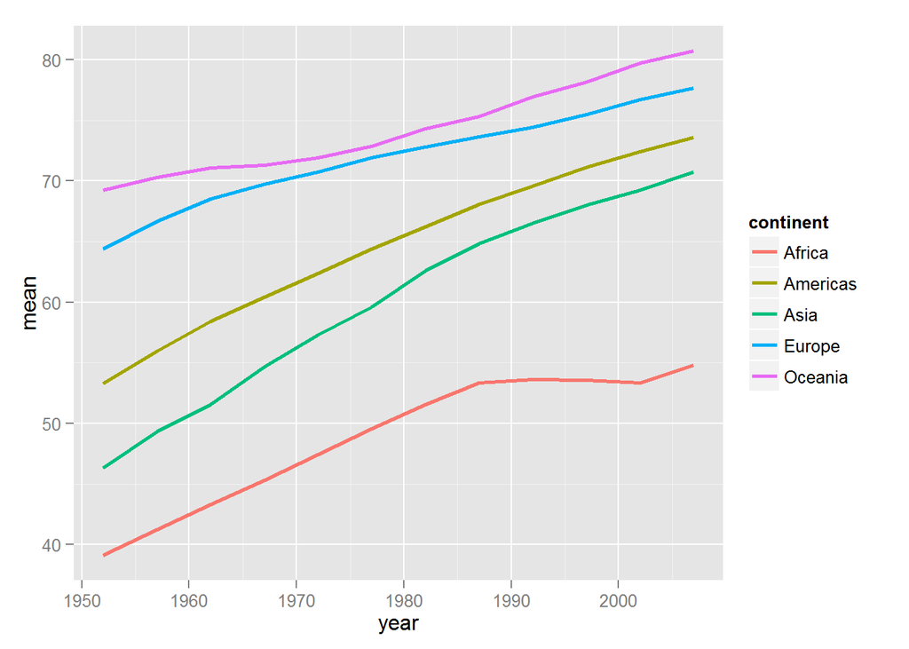

```r
ggplot(gapminder%>%group_by(continent,year)%>%
         summarise(mean=mean(lifeExp))) +
  geom_line(aes(x=year,y=mean,color=continent), size=1)
```

: The life expectancy is continuously rising in all continents, except Africa.

5. Report the absolute and/or relative abundance of countries with low life expectancy over time by continent: Compute some measure of worldwide life expectancy – you decide – a mean or median or some other quantile or perhaps your current age. The determine how many countries on each continent have a life expectancy less than this benchmark, for each year.

```r
life.exp.weighted<-gapminder%>%group_by(year)%>%
  mutate(weighted.mean=weighted.mean(lifeExp,pop),
         lowlifeExp=ifelse(lifeExp<weighted.mean,1,0))
```

: I defined that the country whose life expectancy is below the mean of each year has a low life expectancy. Especially, to reflect the size of population in each country, I used `weighted.mean`. To see whether each country has a low life expectancy, I made a dummy variable named `lowlifeExp`, which prints out “0” when `lifeExp` is higher than `weighted.mean`, and “1” when `lifeExp` is lower than `weighted.mean`.

```r
life.exp.weighted.continent<-life.exp.weighted%>%
  group_by(year,continent)%>%
  summarise(lowlife.mean=round(mean(lowlifeExp),2))
```

```r
#Spread the year-lowlife.mean pair
kable(life.exp.weighted.continent %>%spread(year,lowlife.mean))
```

| continent | 1952 | 1957 | 1962 | 1967 | 1972 | 1977 | 1982 | 1987 | 1992 | 1997 | 2002 | 2007 |
| --- | --- | --- | --- | --- | --- | --- | --- | --- | --- | --- | --- | --- |
| Africa | 0.96 | 0.96 | 0.94 | 0.96 | 0.96 | 0.96 | 0.94 | 0.90 | 0.90 | 0.87 | 0.87 | 0.87 |
| Americas | 0.36 | 0.36 | 0.28 | 0.36 | 0.36 | 0.28 | 0.28 | 0.24 | 0.12 | 0.12 | 0.08 | 0.08 |
| Asia | 0.67 | 0.64 | 0.58 | 0.58 | 0.58 | 0.58 | 0.45 | 0.39 | 0.33 | 0.33 | 0.33 | 0.33 |
| Europe | 0.03 | 0.03 | 0.03 | 0.03 | 0.03 | 0.03 | 0.03 | 0.03 | 0.00 | 0.00 | 0.00 | 0.00 |
| Oceania | 0.00 | 0.00 | 0.00 | 0.00 | 0.00 | 0.00 | 0.00 | 0.00 | 0.00 | 0.00 | 0.00 | 0.00 |

: By calculating the mean of `lowlifeExp` for each year and continent, the proportion of the countries having low life expectancy within contienents can be derived.

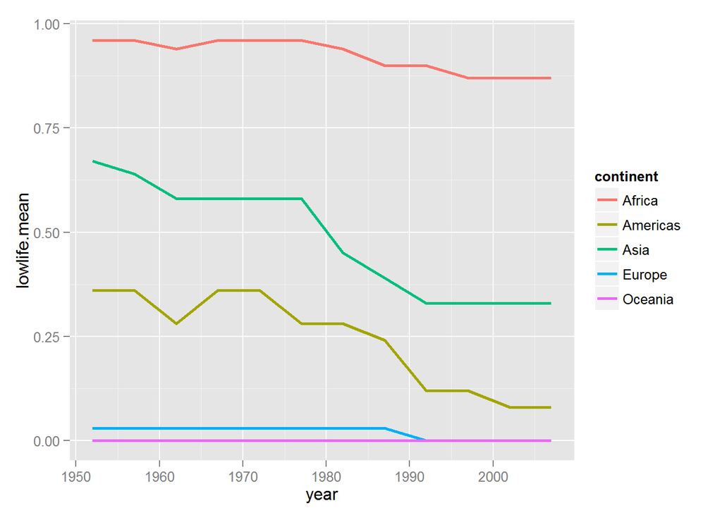

```r
ggplot(life.exp.weighted.continent, aes(x=year,y=lowlife.mean))+
  geom_line(aes(color=continent),size=1)
```

6. Find countries with interesting stories. Open-ended and, therefore, hard. Promising but unsuccessful attempts are encouraged. This will generate interesting questions to follow up on in class.
- I would like to see the changes in life expectancy and GDP per capita within North and South Korea. Before that, I would like to see the correlation between life expectancy and GDP per capita.

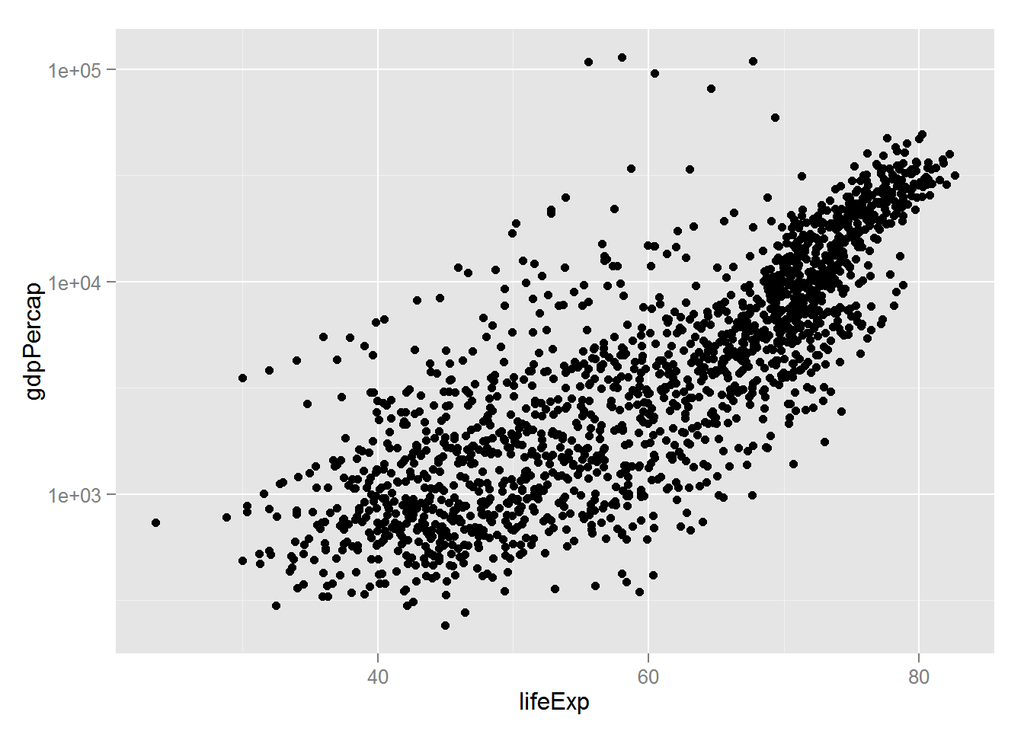

```r
ggplot(gapminder, aes(x=lifeExp,y=gdpPercap))+geom_point()+scale_y_log10()
```

: There seems to be a positive correlation between life expectancy and GDP per capita. Thus, I compared GDP per capita of the two Koreas.

```r
Korea.gdp<-gapminder[grep('Korea',gapminder$country),c(1:2,6)]
```

```r
kable(Korea.gdp%>%mutate(gdpPercap=round(gdpPercap,2))%>%
        spread(year,gdpPercap))
```

| country | 1952 | 1957 | 1962 | 1967 | 1972 | 1977 | 1982 | 1987 | 1992 | 1997 | 2002 | 2007 |
| --- | --- | --- | --- | --- | --- | --- | --- | --- | --- | --- | --- | --- |
| Korea, Dem. Rep. | 1088.28 | 1571.13 | 1621.69 | 2143.54 | 3701.62 | 4106.30 | 4106.53 | 4106.49 | 3726.06 | 1690.76 | 1646.76 | 1593.07 |
| Korea, Rep. | 1030.59 | 1487.59 | 1536.34 | 2029.23 | 3030.88 | 4657.22 | 5622.94 | 8533.09 | 12104.28 | 15993.53 | 19233.99 | 23348.14 |

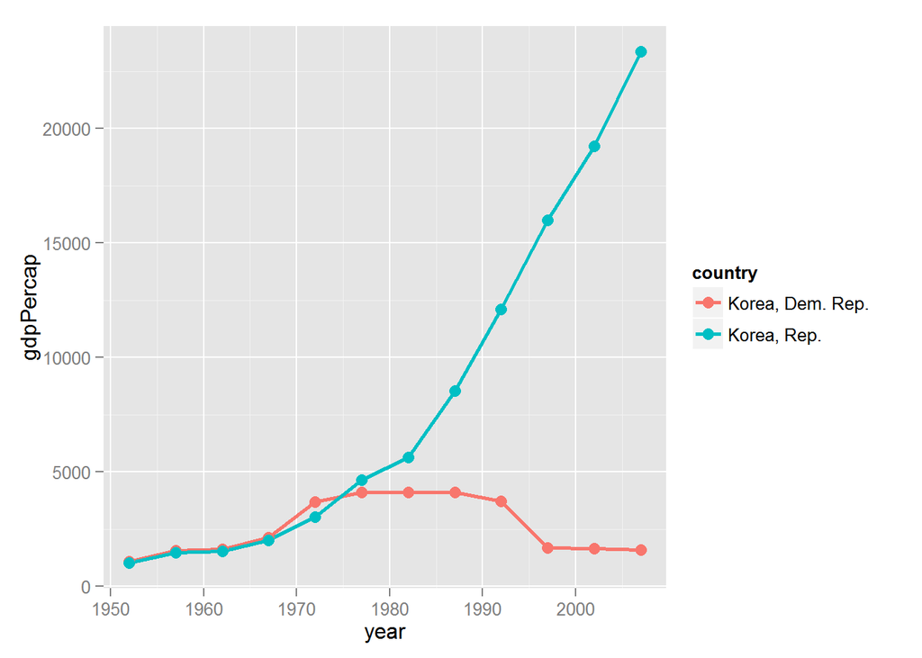

```r
Koreas<-c("Korea, Dem. Rep.","Korea, Rep.")
ggplot(filter(gapminder, country %in% Koreas),
       aes(x=year,y=gdpPercap, color=country))+
  geom_line(size=1)+geom_point(size=3)
```

: As above, GDP per capita of the two Koreas had been similar until mid 1970. However, South Korea’s GDP per capita soared from 1977, and the discrepancy between the two Koreas are widening. According to this result, I expect that the life expectency of South Korea would be higher than that of North Korea from mid 1970s.

```r
Korea.life.exp<-gapminder[grep('Korea',gapminder$country),c(1:2,5)]
```

```r
kable(Korea.life.exp%>%mutate(lifeExp=round(lifeExp,2))%>%
        spread(year,lifeExp))
```

| country | 1952 | 1957 | 1962 | 1967 | 1972 | 1977 | 1982 | 1987 | 1992 | 1997 | 2002 | 2007 |
| --- | --- | --- | --- | --- | --- | --- | --- | --- | --- | --- | --- | --- |
| Korea, Dem. Rep. | 50.06 | 54.08 | 56.66 | 59.94 | 63.98 | 67.16 | 69.10 | 70.65 | 69.98 | 67.73 | 66.66 | 67.30 |
| Korea, Rep. | 47.45 | 52.68 | 55.29 | 57.72 | 62.61 | 64.77 | 67.12 | 69.81 | 72.24 | 74.65 | 77.05 | 78.62 |

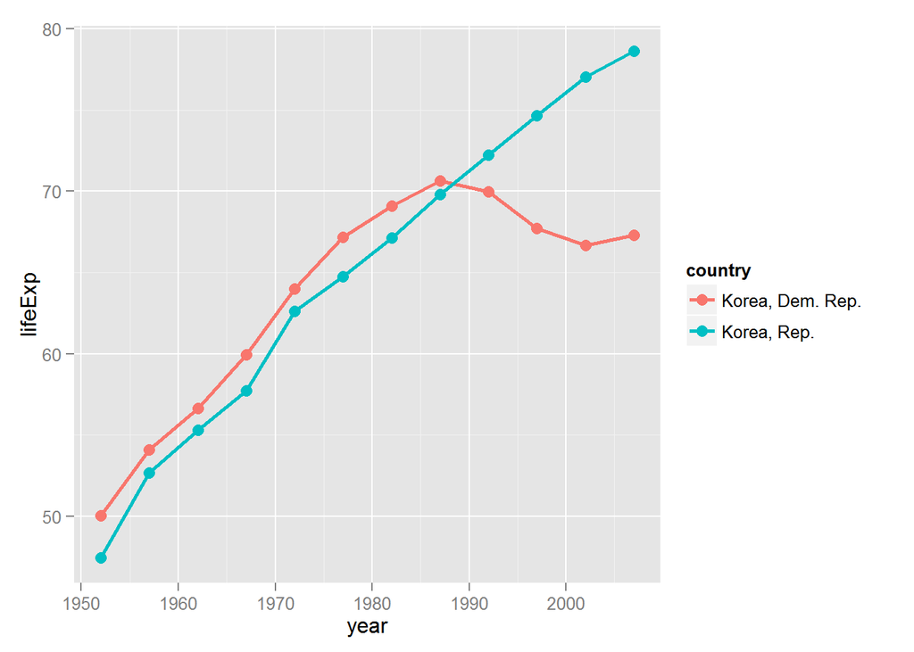

```r
ggplot(filter(gapminder, country %in% Koreas),
       aes(x=year,y=lifeExp, color=country))+
  geom_line(size=1)+geom_point(size=3)
```

: However, the outcome is different from my expectation; the life expectancy in North Korea had been higher than that in South Korea until 1980s. From 1992, the life expectancy of North Korea dropped sharply, while that of South Korea has been consistantly rising. This phenomenon can be understood, considering that there can be some delay for the economic status to be reflected in the life expectancy.

This perspective, however, cannot explain the sudden, simultaneous drop of GDP and life expectancy of North Korea in 1990s.To understand this, its domestic and foreign situation should be considered. With the reunification of Germany in 1990 and the downfall of the Soviet Union in the following year, almost every trade of North Korea stopped, which sent North Korea into deep recession. What is worse, large-scaled natural disasters brought a great famine named *Arduous March* to North Korea from 1995 to 1998. Due to the combination of economic recession and the great famine, approximately 400 thousand people died, which lowered its life expectancy considerably. Hence, it can be concluded that the national crisis can affect the life expectancy immediatly.

In sum, it seems that the change in GDP per capita of one country does not leads to the change of life expectancy in an instant, except when a severe crisis that can threaten the lives of the citizens.